# Does Steven Spielberg beat Tim Burton in IMDB ratings?

IMDb [Internet Movie Database](https://www.imdb.com/) is an online database of information related to films, television programs, home videos, video games, and streaming content – including cast, production crew and personal biographies, plot summaries, trivia, ratings, and fan and critical reviews.

Originally a fan-operated website, the database is today owned and operated by IMDb.com, Inc., a subsidiary of Amazon.

As of January 2020, IMDb has approximately 6.5 million titles (including episodes) and 10.4 million personalities in its database as well as 83 million registered users.

In the following I will explore the difference in IMDB ratings for Steven Spielberg and Tim Burton movies.

First, I take a look at the IMDB Dataset using `skimr::skim` and construct a table containing summary statistics to get an overview of the IMDb dataset.

```r
movies <- read_csv(here::here("data", "movies.csv"))
skim(movies)
```

Data summary

| Name | movies |
| --- | --- |
| Number of rows | 2961 |
| Number of columns | 11 |
| _______________________ |  |
| Column type frequency: |  |
| character | 3 |
| numeric | 8 |
| ________________________ |  |
| Group variables | None |

**Variable type: character**

| skim_variable | n_missing | complete_rate | min | max | empty | n_unique | whitespace |
| --- | --- | --- | --- | --- | --- | --- | --- |
| title | 0 | 1 | 1 | 83 | 0 | 2907 | 0 |
| genre | 0 | 1 | 5 | 11 | 0 | 17 | 0 |
| director | 0 | 1 | 3 | 32 | 0 | 1366 | 0 |

**Variable type: numeric**

| skim_variable | n_missing | complete_rate | mean | sd | p0 | p25 | p50 | p75 | p100 | hist |
| --- | --- | --- | --- | --- | --- | --- | --- | --- | --- | --- |
| year | 0 | 1 | 2.00e+03 | 9.95e+00 | 1920.0 | 2.00e+03 | 2.00e+03 | 2.01e+03 | 2.02e+03 | ▁▁▁▂▇ |
| duration | 0 | 1 | 1.10e+02 | 2.22e+01 | 37.0 | 9.50e+01 | 1.06e+02 | 1.19e+02 | 3.30e+02 | ▃▇▁▁▁ |
| gross | 0 | 1 | 5.81e+07 | 7.25e+07 | 703.0 | 1.23e+07 | 3.47e+07 | 7.56e+07 | 7.61e+08 | ▇▁▁▁▁ |
| budget | 0 | 1 | 4.06e+07 | 4.37e+07 | 218.0 | 1.10e+07 | 2.60e+07 | 5.50e+07 | 3.00e+08 | ▇▂▁▁▁ |
| cast_facebook_likes | 0 | 1 | 1.24e+04 | 2.05e+04 | 0.0 | 2.24e+03 | 4.60e+03 | 1.69e+04 | 6.57e+05 | ▇▁▁▁▁ |
| votes | 0 | 1 | 1.09e+05 | 1.58e+05 | 5.0 | 1.99e+04 | 5.57e+04 | 1.33e+05 | 1.69e+06 | ▇▁▁▁▁ |
| reviews | 0 | 1 | 5.03e+02 | 4.94e+02 | 2.0 | 1.99e+02 | 3.64e+02 | 6.31e+02 | 5.31e+03 | ▇▁▁▁▁ |
| rating | 0 | 1 | 6.39e+00 | 1.05e+00 | 1.6 | 5.80e+00 | 6.50e+00 | 7.10e+00 | 9.30e+00 | ▁▁▆▇▁ |

```r
selected_directors <- movies %>%

  select(director, rating) %>%

  filter(director == "Steven Spielberg" | director == "Tim Burton") %>%

  group_by(director) %>%

  summarize(avg = mean(rating),
            sd = sd(rating),
            count = n(),
            tstat = qt(0.975, count-1),
            se = sd/sqrt(count),
            lower_ci = avg - tstat*se,
            upper_ci = avg + tstat*se)

selected_directors %>%

  kable() %>%

  kable_classic()
```

| director | avg | sd | count | tstat | se | lower_ci | upper_ci |
| --- | --- | --- | --- | --- | --- | --- | --- |
| Steven Spielberg | 7.57 | 0.695 | 23 | 2.07 | 0.145 | 7.27 | 7.87 |
| Tim Burton | 6.93 | 0.749 | 16 | 2.13 | 0.187 | 6.53 | 7.33 |

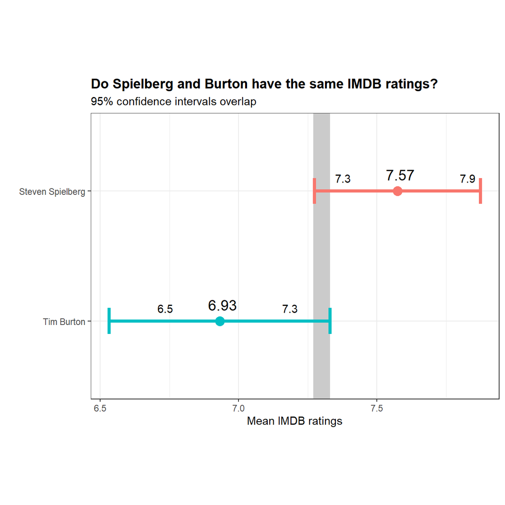

```r
# Selecting Spielberg and Burton

selected_directors <- movies %>%

  filter(director == "Steven Spielberg" | director == "Tim Burton") %>%

  group_by(director) %>%

  summarise(
    mean = mean(rating),
    sd = sd(rating),
    count = n(),
    se = sd / sqrt(count),
    tstat = qt(0.975, count - 1),
    lower_ci = mean - tstat * se,
    upper_ci = mean + tstat * se)

# Reproducing the plot

ggplot(selected_directors, aes(
                            x = mean,
                            y = reorder(director, mean))) +

# Adding area where confidence intervals overlap

  geom_rect(xmin = 7.27,
            xmax = 7.33,
            ymin = 0,
            ymax = 10,
            fill = "grey",
            aes(alpha = 0.5)) +

# Adding points to plot the mean

  geom_point(aes(
            color = director),
            size = 4) +


# Adding confidence interval error bars

  geom_errorbar(aes(
                    xmin = lower_ci,
                    xmax = upper_ci,
                    colour = director,
                    fill = director),
                    width = 0.2,
                    size = 1.5) +

# Adding mean labels

  geom_text(aes(
            label = round(mean, 2)),
            size = 5,
            hjust = 0.4,
            vjust = -1) +

# Setting fill colors

  scale_fill_manual(values = c("#FA8072", "#48D1CC")) +

# Adding confidence interval labels

  geom_text(aes(
                label = round(lower_ci, 1.4)),
                hjust = 4,
                vjust = - 1) +

  geom_text(aes(
                label = round(upper_ci, 1.4)),
                hjust = - 4,
                vjust = - 1) +

# Adding theme

  theme_bw() +

# Removing legend

  theme(legend.position = "none") +

# Adding titles to plot and axes

  theme(plot.title = element_text(face = "bold")) +

  labs(title = "Do Spielberg and Burton have the same IMDB ratings?",
       subtitle = "95% confidence intervals overlap",
       x = "Mean IMDB ratings",
       y = "") +

# Adjusting size

  theme(aspect.ratio=3.5/5)
```

> The plot displays a difference in the mean IMDb ratings for the directors although there is an opverlap in ratings.

To test for a difference in mean ratings for Steven Spielberg and Tim Burton movies, I will perform a hypothesis test with the hypotheses being:

1. Null hypothesis (H0): There is no difference between the mean ratings for Spielberg and Burton
2. Alternative hypothesis (H1): There is a difference between the mean ratings for Spielberg and Burton

```r
selected_directors <- movies %>%
  select(director, rating) %>%
  filter(director == "Steven Spielberg" | director == "Tim Burton")
t.test(rating ~ director, selected_directors)
```

```
##
##  Welch Two Sample t-test
##
## data:  rating by director
## t = 3, df = 31, p-value = 0.01
## alternative hypothesis: true difference in means is not equal to 0
## 95 percent confidence interval:
##  0.16 1.13
## sample estimates:
## mean in group Steven Spielberg       mean in group Tim Burton
##                           7.57                           6.93
```

> The t-test shows that we have to reject the null hypothesis as the p-value is equal to 0.01 and hence < alpha value of 0.05. Hence, we can infer from the analysis that there is evidence that Steven Spielberg and Tim Burton have differing mean ratings.

We can also obtain the p-value using the `infer` package.

```r
set.seed(1234)

# Running a simulation with the infer package

hypothesis_test <- selected_directors %>%

  specify(rating ~ director) %>%

# Null hypothesis is that there is no difference between the two population means

  hypothesise(null="independence") %>%

  generate(reps=1000,
           type="permute") %>%

# Obtaining difference in means with bootstrap function

  calculate(stat="diff in means",
            order = c("Steven Spielberg","Tim Burton"))

difference_ratings <- selected_directors %>%

  specify(rating ~ director) %>%

  calculate(stat = "diff in means", order = c("Steven Spielberg","Tim Burton"))

# Get p_Value through infer package

p_value <- hypothesis_test %>%

  get_p_value(obs_stat = difference_ratings,
              direction = "both")

kbl(p_value,
    col.names=c("p-value"),
    caption="Null distribution") %>%

kable_classic()
```

Null distribution

| p-value |
| --- |
| 0.008 |

> The simulation-based test shows again that the p-value is < the alpha value. Hence, we reject the null-hypothesis. There is a statistically evident difference in mean ratings for both directors.